# r-statistics

Fernando Millan Villalobos

2022-10-10

# 1 Notes

This report was generated on 2022-10-10 15:39:30. R version: 4.2.1 on aarch64-apple-darwin20. For this report, CRAN packages as of 2022-10-01 were used.

…

## 1.1 R-Script & data

The preprocessing and analysis of the data was conducted in the [R project for statistical computing](https://www.r-project.org/). The RMarkdown script used to generate this document and all the resulting data can be downloaded [under this link](http://fernandomillanvillalobos.github.io/r-statistics/). Through executing `main.Rmd`, the herein described process can be reproduced and this document can be generated. In the course of this, data from the folder `input` will be processed and results will be written to `output`. The html on-line version of the analysis can be accessed through this [link](https://fernandomillanvillalobos.github.io/r-statistics/).

## 1.2 GitHub

The code for the herein described process can also be freely downloaded from https://github.com/fernandomillanvillalobos/r-statistics.

## 1.3 License

…

## 1.4 Data description of output files

#### 1.4.0.1 `abc.csv` (Example)

| Attribute | Type | Description |
| --- | --- | --- |
| a | Numeric | … |
| b | Numeric | … |
| c | Numeric | … |

…

# 2 Set up

```
## [1] "package package:rmarkdown detached"
```

## 2.1 Define packages

```r
# from https://mran.revolutionanalytics.com/web/packages/\
# checkpoint/vignettes/using-checkpoint-with-knitr.html
# if you don't need a package, remove it from here (commenting not sufficient)
# tidyverse: see https://blog.rstudio.org/2016/09/15/tidyverse-1-0-0/
cat("
library(rstudioapi)
library(tidyverse)
library(tidylog)
library(jsonlite)
library(lintr)
library(rmarkdown)
library(rio)
library(cowplot)
library(extrafont)
library(ggrepel)
library(scales)
library(gapminder)
library(broom)
library(janitor)",
file = "manifest.R")
```

## 2.2 Install packages

```r
# if checkpoint is not yet installed, install it (for people using this
# system for the first time)
if (!require(checkpoint)) {
  if (!require(devtools)) {
    install.packages("devtools", repos = "http://cran.us.r-project.org")
    require(devtools)
  }
  devtools::install_github("RevolutionAnalytics/checkpoint",
                           ref = "v0.3.2", # could be adapted later,
                           # as of now (beginning of July 2017
                           # this is the current release on CRAN)
                           repos = "http://cran.us.r-project.org")
  require(checkpoint)
}
# nolint start
if (!dir.exists("~/.checkpoint")) {
  dir.create("~/.checkpoint")
}
# nolint end
# install packages for the specified CRAN snapshot date
checkpoint(snapshot_date = package_date,
           project = path_to_wd,
           verbose = T,
           scanForPackages = T,
           use.knitr = F,
           R.version = r_version)
rm(package_date)
```

## 2.3 Load packages

```r
source("manifest.R")
unlink("manifest.R")
```

## 2.4 Load additional scripts

```r
# if you want to outsource logic to other script files, see README for
# further information
# Load all visualizations functions as separate scripts
knitr::read_chunk("scripts/dviz.supp.R")
source("scripts/dviz.supp.R")
knitr::read_chunk("scripts/themes.R")
source("scripts/themes.R")
knitr::read_chunk("scripts/plot_grid.R")
source("scripts/plot_grid.R")
knitr::read_chunk("scripts/align_legend.R")
source("scripts/align_legend.R")
knitr::read_chunk("scripts/label_log10.R")
source("scripts/label_log10.R")
knitr::read_chunk("scripts/outliers.R")
source("scripts/outliers.R")
knitr::read_chunk("scripts/api-keys.R")
source("scripts/api-keys.R")
```

# 3 Inferential Statistics

## 3.1 Linear regression

To perform further analysis with the parameters of our model, we can pipe the model into the tidy function from the **broom** package. To apply the same model to each variable (e.g. country) is to use the `split > apply > combine` technique. The combination of `group_by` and `summarise` is a method of `split > apply > combine`. Another method for `slice > apply > combine` is to use `group_by` with `slice_max`, and `ungroup`. `\(.x)` is a shorthand option for an anonymous function in R. It was introduced with R 4.1.0. There is not just one way to run many models with the Tidyverse, but many.

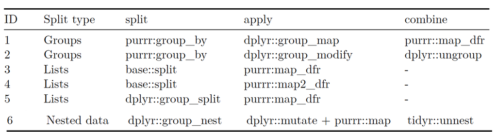

Ways of run many models with Tidyverse

First of all, we can differentiate between the three split types:

- *group*: When we talk about groups, we mean that the data is in the form of a grouped tibble.
- *lists*: By lists we mean the native list data type
- *nested_data*: By nested data, we mean nested data frames in which columns of a data frame contain lists or data frames.

Some methods combine the `apply > combine` step into one function (`split > map_dfr` and `split -> map2_dfr`). All methods have in common that a data frame comes in and a data frame goes out. What kind of data frame is returned depends on what we do in the apply phase. In our case, we chose to output the test statistics or parameters of our models. Similarly, we could also output the predictions of our models.

`group_map` function takes a grouped tibble as input and outputs a list. Before this function, we could not simply iterate a function over groups in a grouped tibble. Instead, we split data frames into a list and applied **purrr** functions to the elements of that list (e.g., map). If you like, `group_map` is the **dplyr** version of **purrr’s** `map` functions.

Compared to `group_map`, this function also accepts a grouped tibble, but outputs a grouped tibble instead of a list. With `group_modify` you have to make sure that a data frame is returned, otherwise the function will yield an error. The great advantage of this method is that we can other the country and continent as columns. The beauty of keeping the country and continent columns is that we can now compare the fit of our model to the actual life expectancies in these countries. To get this data, we can use the `augment` function from the **broom** package. For each country, the function returns the fitted values of our dependent variable (in our case life expectancy), the residuals and the actual values of the dependent variable.

The combination of `group_split` and `map_dfr` is just an alternative version of `split` and `map_dfr`. `group_split` was introduced in **dplyr** for version 0.8.0 in 2019. It is still in an experimental state. The difference with `split` is that `group_split` does not name the elements of the returned list.

The `group_nest` function was also introduced with the **dplyr** version 0.8.0 and works pretty similar to nest. Compared to `nest`, with `group_nest` you name the columns that should not be nested instead of the columns that should be nested.

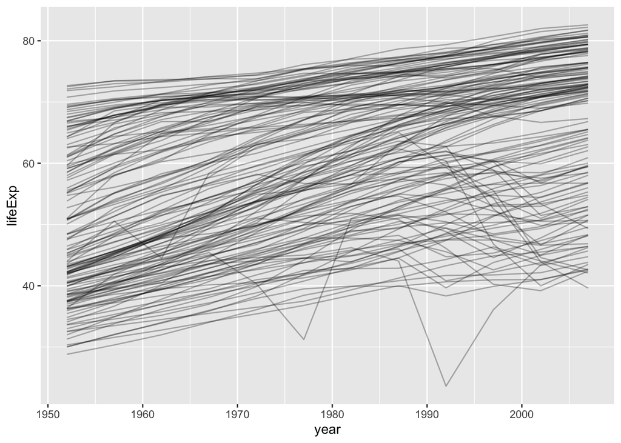

```r
# plotting the development of life expectancy
ggplot(
  gapminder,
  aes(x = year, y = lifeExp, group = country)
) +
  geom_line(alpha = .3)
```

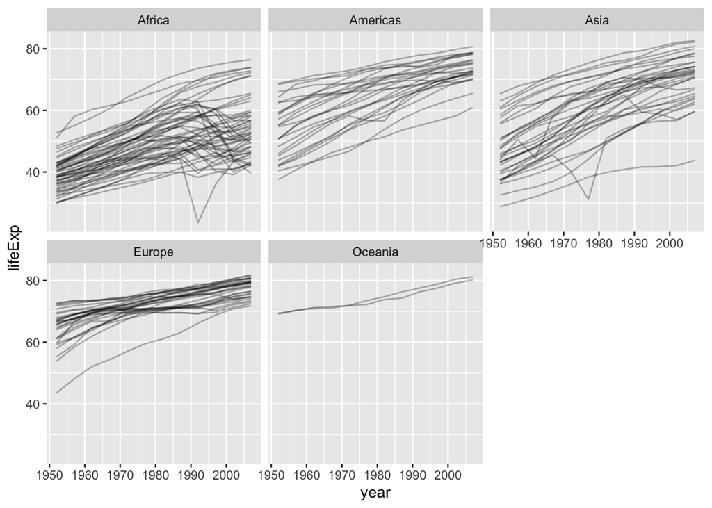

```r
ggplot(
  gapminder,
  aes(x = year, y = lifeExp, group = country)
) +
  geom_line(alpha = .3) +
  facet_wrap(vars(continent))
```

```r
# building a linear model
model <- lm(lifeExp ~ year, data = gapminder)
summary(model)
```

```
##
## Call:
## lm(formula = lifeExp ~ year, data = gapminder)
##
## Residuals:
##     Min      1Q  Median      3Q     Max
## -39.949  -9.651   1.697  10.335  22.158
##
## Coefficients:
##               Estimate Std. Error t value            Pr(>|t|)
## (Intercept) -585.65219   32.31396  -18.12 <0.0000000000000002 ***
## year           0.32590    0.01632   19.96 <0.0000000000000002 ***
## ---
## Signif. codes:  0 '***' 0.001 '**' 0.01 '*' 0.05 '.' 0.1 ' ' 1
##
## Residual standard error: 11.63 on 1702 degrees of freedom
## Multiple R-squared:  0.1898, Adjusted R-squared:  0.1893
## F-statistic: 398.6 on 1 and 1702 DF,  p-value: < 0.00000000000000022
```

```r
# further analysis using the data extracted from the linear model
model %>%
  tidy()
```

```
## # A tibble: 2 × 5
##   term        estimate std.error statistic  p.value
##   <chr>          <dbl>     <dbl>     <dbl>    <dbl>
## 1 (Intercept) -586.      32.3        -18.1 2.90e-67
## 2 year           0.326    0.0163      20.0 7.55e-80
```

```r
# getting the test statistics of our model
model %>%
  broom::glance()
```

```
## # A tibble: 1 × 12
##   r.squared adj.r.sq…¹ sigma stati…²  p.value    df logLik    AIC    BIC devia…³
##       <dbl>      <dbl> <dbl>   <dbl>    <dbl> <dbl>  <dbl>  <dbl>  <dbl>   <dbl>
## 1     0.190      0.189  11.6    399. 7.55e-80     1 -6598. 13202. 13218. 230229.
## # … with 2 more variables: df.residual <int>, nobs <int>, and abbreviated
## #   variable names ¹adj.r.squared, ²statistic, ³deviance
```

```r
# calculating the mean per continent and year
(group_by_summarise_example <- gapminder %>%
  group_by(continent, year) %>%
  summarise(mean = mean(lifeExp, na.rm = TRUE)) %>%
  ungroup())
```

```
## # A tibble: 60 × 3
##    continent  year  mean
##    <fct>     <int> <dbl>
##  1 Africa     1952  39.1
##  2 Africa     1957  41.3
##  3 Africa     1962  43.3
##  4 Africa     1967  45.3
##  5 Africa     1972  47.5
##  6 Africa     1977  49.6
##  7 Africa     1982  51.6
##  8 Africa     1987  53.3
##  9 Africa     1992  53.6
## 10 Africa     1997  53.6
## # … with 50 more rows
```

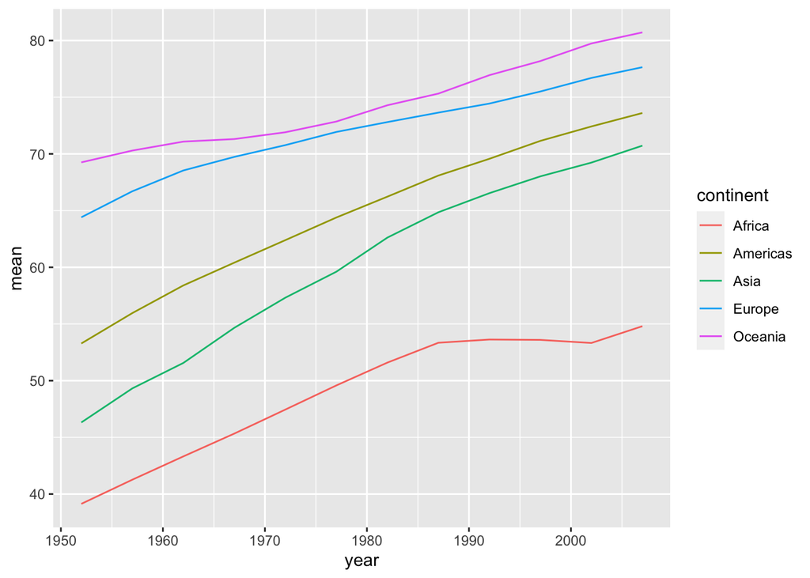

```r
# plotting the results
group_by_summarise_example %>%
  ggplot(aes(x = year, y = mean)) +
  geom_line(aes(color = continent))
```

```r
# finding for each continent the year in which life expectancy was highest over the last 50 years
(group_by_with_slice_max <- gapminder %>%
  group_by(continent) %>%
  slice_max(lifeExp, n = 1) %>%
  ungroup())
```

```
## # A tibble: 5 × 6
##   country   continent  year lifeExp       pop gdpPercap
##   <fct>     <fct>     <int>   <dbl>     <int>     <dbl>
## 1 Reunion   Africa     2007    76.4    798094     7670.
## 2 Canada    Americas   2007    80.7  33390141    36319.
## 3 Japan     Asia       2007    82.6 127467972    31656.
## 4 Iceland   Europe     2007    81.8    301931    36181.
## 5 Australia Oceania    2007    81.2  20434176    34435.
```

```r
# running the same linear model for each country
(test_statistics <- gapminder %>%
  split(.$country) %>% # split the data frame into a list. Each list element contains a data frame of one country
  map_dfr(\(.x) lm(lifeExp ~ year, .x) %>% # loop over the data frame of each country -> apply two functions at once: map_dfr() and lm()
    broom::glance())) # extract the test statistics from the model object
```

```
## # A tibble: 142 × 12
##    r.squared adj.r.squ…¹ sigma stati…²  p.value    df logLik   AIC   BIC devia…³
##        <dbl>       <dbl> <dbl>   <dbl>    <dbl> <dbl>  <dbl> <dbl> <dbl>   <dbl>
##  1     0.948       0.942 1.22    181.  9.84e- 8     1 -18.3  42.7  44.1   15.0
##  2     0.911       0.902 1.98    102.  1.46e- 6     1 -24.1  54.3  55.8   39.3
##  3     0.985       0.984 1.32    662.  1.81e-10     1 -19.3  44.6  46.0   17.5
##  4     0.888       0.877 1.41     79.1 4.59e- 6     1 -20.0  46.1  47.5   19.8
##  5     0.996       0.995 0.292  2246.  4.22e-13     1  -1.17  8.35  9.80   0.854
##  6     0.980       0.978 0.621   481.  8.67e-10     1 -10.2  26.4  27.9    3.85
##  7     0.992       0.991 0.407  1261.  7.44e-12     1  -5.16 16.3  17.8    1.66
##  8     0.967       0.963 1.64    291.  1.02e- 8     1 -21.9  49.7  51.2   26.9
##  9     0.989       0.988 0.977   930.  3.37e-11     1 -15.7  37.3  38.8    9.54
## 10     0.995       0.994 0.293  1822.  1.20e-12     1  -1.20  8.40  9.85   0.858
## # … with 132 more rows, 2 more variables: df.residual <int>, nobs <int>, and
## #   abbreviated variable names ¹adj.r.squared, ²statistic, ³deviance
```

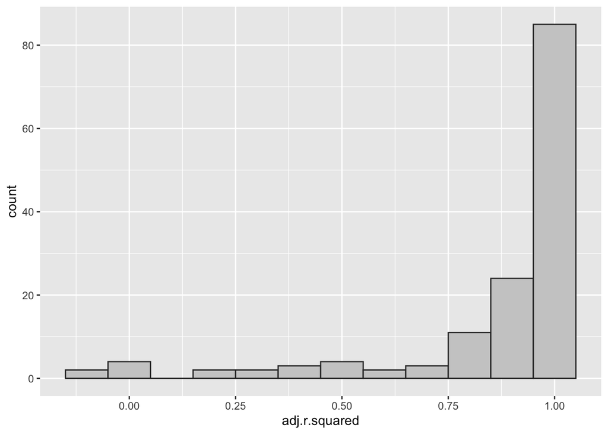

```r
# looking at the adjusted R-squared
test_statistics %>%
  ggplot(aes(x = adj.r.squared)) +
  geom_histogram(binwidth = .1, fill = "grey80", color = "gray20")
```

```r
#  ways to run many models with the Tidyverse
# using grouped data with group_map()
gapminder %>%
  group_by(country) %>%
  group_map(
    .data = .,
    .f = ~ lm(lifeExp ~ year, data = .) %>% glance()
  ) %>% # get the test statistics
  map_dfr(~.) # combine the list of a data frames obtained in one data frame
```

```
## # A tibble: 142 × 12
##    r.squared adj.r.squ…¹ sigma stati…²  p.value    df logLik   AIC   BIC devia…³
##        <dbl>       <dbl> <dbl>   <dbl>    <dbl> <dbl>  <dbl> <dbl> <dbl>   <dbl>
##  1     0.948       0.942 1.22    181.  9.84e- 8     1 -18.3  42.7  44.1   15.0
##  2     0.911       0.902 1.98    102.  1.46e- 6     1 -24.1  54.3  55.8   39.3
##  3     0.985       0.984 1.32    662.  1.81e-10     1 -19.3  44.6  46.0   17.5
##  4     0.888       0.877 1.41     79.1 4.59e- 6     1 -20.0  46.1  47.5   19.8
##  5     0.996       0.995 0.292  2246.  4.22e-13     1  -1.17  8.35  9.80   0.854
##  6     0.980       0.978 0.621   481.  8.67e-10     1 -10.2  26.4  27.9    3.85
##  7     0.992       0.991 0.407  1261.  7.44e-12     1  -5.16 16.3  17.8    1.66
##  8     0.967       0.963 1.64    291.  1.02e- 8     1 -21.9  49.7  51.2   26.9
##  9     0.989       0.988 0.977   930.  3.37e-11     1 -15.7  37.3  38.8    9.54
## 10     0.995       0.994 0.293  1822.  1.20e-12     1  -1.20  8.40  9.85   0.858
## # … with 132 more rows, 2 more variables: df.residual <int>, nobs <int>, and
## #   abbreviated variable names ¹adj.r.squared, ²statistic, ³deviance
```

```r
# using grouped data with group_modify()
(method_two_results <- gapminder %>%
  group_by(country, continent) %>%
  group_modify(
    .data = .,
    .f = ~ lm(lifeExp ~ year, data = .) %>% glance()
  ) %>%
  ungroup())
```

```
## # A tibble: 142 × 14
##    country     conti…¹ r.squ…² adj.r…³ sigma stati…⁴  p.value    df logLik   AIC
##    <fct>       <fct>     <dbl>   <dbl> <dbl>   <dbl>    <dbl> <dbl>  <dbl> <dbl>
##  1 Afghanistan Asia      0.948   0.942 1.22    181.  9.84e- 8     1 -18.3  42.7
##  2 Albania     Europe    0.911   0.902 1.98    102.  1.46e- 6     1 -24.1  54.3
##  3 Algeria     Africa    0.985   0.984 1.32    662.  1.81e-10     1 -19.3  44.6
##  4 Angola      Africa    0.888   0.877 1.41     79.1 4.59e- 6     1 -20.0  46.1
##  5 Argentina   Americ…   0.996   0.995 0.292  2246.  4.22e-13     1  -1.17  8.35
##  6 Australia   Oceania   0.980   0.978 0.621   481.  8.67e-10     1 -10.2  26.4
##  7 Austria     Europe    0.992   0.991 0.407  1261.  7.44e-12     1  -5.16 16.3
##  8 Bahrain     Asia      0.967   0.963 1.64    291.  1.02e- 8     1 -21.9  49.7
##  9 Bangladesh  Asia      0.989   0.988 0.977   930.  3.37e-11     1 -15.7  37.3
## 10 Belgium     Europe    0.995   0.994 0.293  1822.  1.20e-12     1  -1.20  8.40
## # … with 132 more rows, 4 more variables: BIC <dbl>, deviance <dbl>,
## #   df.residual <int>, nobs <int>, and abbreviated variable names ¹continent,
## #   ²r.squared, ³adj.r.squared, ⁴statistic
```

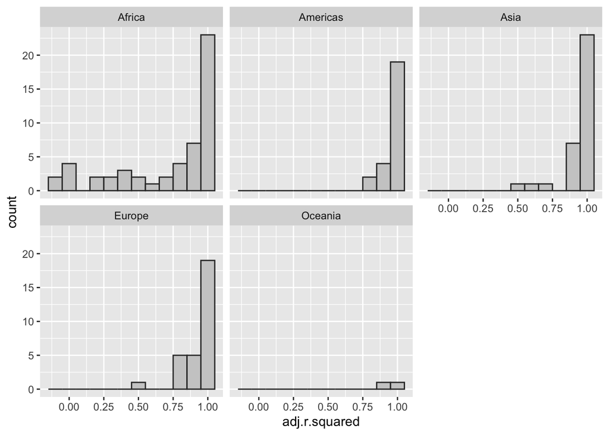

```r
# plotting the results
method_two_results %>%
  ggplot(aes(x = adj.r.squared)) +
  geom_histogram(binwidth = .1, fill = "grey80", color = "gray20") +
  facet_wrap(vars(continent))
```

```r
# showing the countries with the worst fit
method_two_results %>%
  slice_min(adj.r.squared, n = 5)
```

```
## # A tibble: 5 × 14
##   country conti…¹ r.squ…² adj.r…³ sigma stati…⁴ p.value    df logLik   AIC   BIC
##   <fct>   <fct>     <dbl>   <dbl> <dbl>   <dbl>   <dbl> <dbl>  <dbl> <dbl> <dbl>
## 1 Rwanda  Africa   0.0172 -0.0811  6.56   0.175   0.685     1  -38.5  83.0  84.5
## 2 Botswa… Africa   0.0340 -0.0626  6.11   0.352   0.566     1  -37.7  81.3  82.8
## 3 Zimbab… Africa   0.0562 -0.0381  7.21   0.596   0.458     1  -39.6  85.3  86.7
## 4 Zambia  Africa   0.0598 -0.0342  4.53   0.636   0.444     1  -34.1  74.1  75.6
## 5 Swazil… Africa   0.0682 -0.0250  6.64   0.732   0.412     1  -38.7  83.3  84.8
## # … with 3 more variables: deviance <dbl>, df.residual <int>, nobs <int>, and
## #   abbreviated variable names ¹continent, ²r.squared, ³adj.r.squared,
## #   ⁴statistic
```

```r
# comparing the fit of our model to the actual life expectancies in these countries
(augmented_data <- gapminder %>%
  group_by(country, continent) %>%
  group_modify(
    .data = .,
    .f = ~ lm(lifeExp ~ year, data = .) %>% augment()
  ) %>%
  ungroup())
```

```
## # A tibble: 1,704 × 10
##    country   conti…¹ lifeExp  year .fitted  .resid   .hat .sigma .cooksd .std.…²
##    <fct>     <fct>     <dbl> <int>   <dbl>   <dbl>  <dbl>  <dbl>   <dbl>   <dbl>
##  1 Afghanis… Asia       28.8  1952    29.9 -1.11   0.295    1.21 2.43e-1 -1.08
##  2 Afghanis… Asia       30.3  1957    31.3 -0.952  0.225    1.24 1.13e-1 -0.884
##  3 Afghanis… Asia       32.0  1962    32.7 -0.664  0.169    1.27 3.60e-2 -0.595
##  4 Afghanis… Asia       34.0  1967    34.0 -0.0172 0.127    1.29 1.65e-5 -0.0151
##  5 Afghanis… Asia       36.1  1972    35.4  0.674  0.0991   1.27 1.85e-2  0.581
##  6 Afghanis… Asia       38.4  1977    36.8  1.65   0.0851   1.15 9.23e-2  1.41
##  7 Afghanis… Asia       39.9  1982    38.2  1.69   0.0851   1.15 9.67e-2  1.44
##  8 Afghanis… Asia       40.8  1987    39.5  1.28   0.0991   1.21 6.67e-2  1.10
##  9 Afghanis… Asia       41.7  1992    40.9  0.754  0.127    1.26 3.17e-2  0.660
## 10 Afghanis… Asia       41.8  1997    42.3 -0.534  0.169    1.27 2.33e-2 -0.479
## # … with 1,694 more rows, and abbreviated variable names ¹continent,
## #   ².std.resid
```

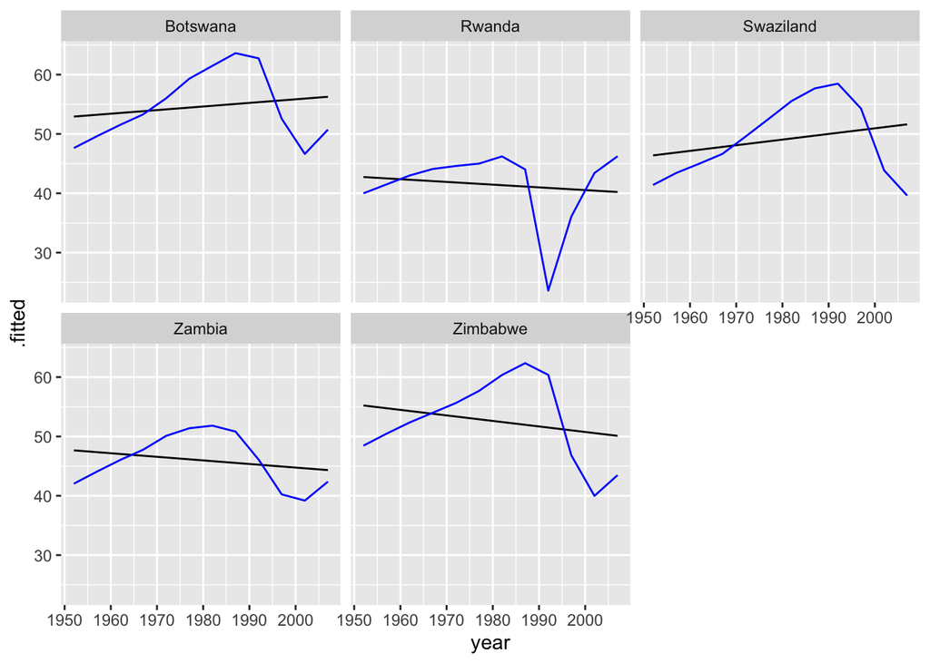

```r
# comparing our regression models for the bottom five countries with the actual data
augmented_data %>%
  filter(country %in% (
    method_two_results %>% slice_min(adj.r.squared, n = 5) %>%
      pull(country)
  )) %>%
  ggplot(aes(x = year, y = .fitted)) +
  geom_line() +
  geom_line(aes(y = .fitted + .resid), color = "blue") +
  facet_wrap(vars(country))
```

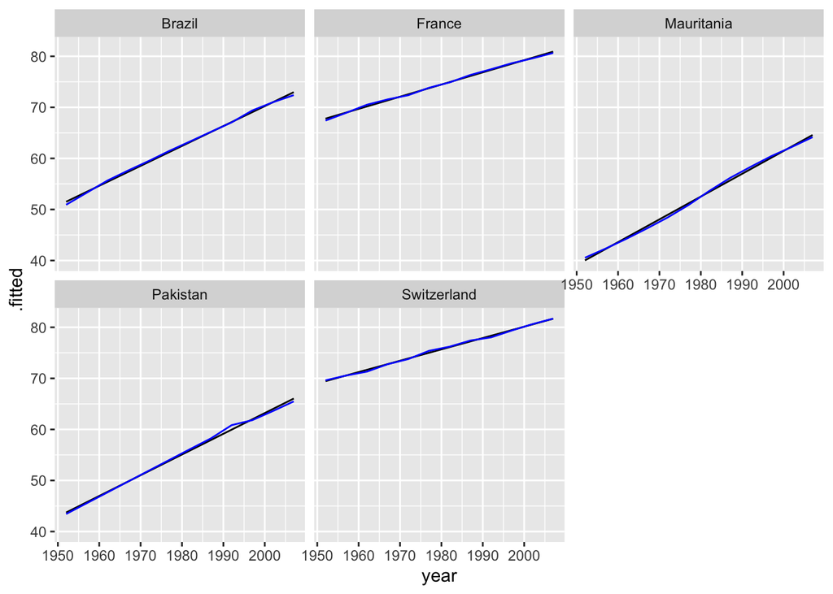

```r
# the top five countries
augmented_data %>%
  filter(country %in% (
    method_two_results %>% slice_max(adj.r.squared, n = 5) %>%
      pull(country)
  )) %>%
  ggplot(aes(x = year, y = .fitted)) +
  geom_line() +
  geom_line(aes(y = .fitted + .resid), color = "blue") +
  facet_wrap(vars(country))
```

```r
# using split and map_dfr but keeping countries and continent
gapminder %>%
  split(.$country) %>%
  map_dfr(
    .x = .,
    .f = ~ lm(lifeExp ~ year, data = .x) %>%
      tidy() %>%
      mutate(
        country = .x$country[1],
        continent = .x$continent[1]
      )
  )
```

```
## # A tibble: 284 × 7
##    term         estimate std.error statistic  p.value country     continent
##    <chr>           <dbl>     <dbl>     <dbl>    <dbl> <fct>       <fct>
##  1 (Intercept)  -508.     40.5        -12.5  1.93e- 7 Afghanistan Asia
##  2 year            0.275   0.0205      13.5  9.84e- 8 Afghanistan Asia
##  3 (Intercept)  -594.     65.7         -9.05 3.94e- 6 Albania     Europe
##  4 year            0.335   0.0332      10.1  1.46e- 6 Albania     Europe
##  5 (Intercept) -1068.     43.8        -24.4  3.07e-10 Algeria     Africa
##  6 year            0.569   0.0221      25.7  1.81e-10 Algeria     Africa
##  7 (Intercept)  -377.     46.6         -8.08 1.08e- 5 Angola      Africa
##  8 year            0.209   0.0235       8.90 4.59e- 6 Angola      Africa
##  9 (Intercept)  -390.      9.68       -40.3  2.14e-12 Argentina   Americas
## 10 year            0.232   0.00489     47.4  4.22e-13 Argentina   Americas
## # … with 274 more rows
```

```r
# using group_split() instead of split()
gapminder %>%
  group_split(country) %>%
  map_dfr(
    .x = .,
    .f = ~ lm(lifeExp ~ year, data = .x) %>%
      tidy() %>%
      mutate(
        country = .x$country[1],
        continent = .x$continent[1]
      )
  )
```

```
## # A tibble: 284 × 7
##    term         estimate std.error statistic  p.value country     continent
##    <chr>           <dbl>     <dbl>     <dbl>    <dbl> <fct>       <fct>
##  1 (Intercept)  -508.     40.5        -12.5  1.93e- 7 Afghanistan Asia
##  2 year            0.275   0.0205      13.5  9.84e- 8 Afghanistan Asia
##  3 (Intercept)  -594.     65.7         -9.05 3.94e- 6 Albania     Europe
##  4 year            0.335   0.0332      10.1  1.46e- 6 Albania     Europe
##  5 (Intercept) -1068.     43.8        -24.4  3.07e-10 Algeria     Africa
##  6 year            0.569   0.0221      25.7  1.81e-10 Algeria     Africa
##  7 (Intercept)  -377.     46.6         -8.08 1.08e- 5 Angola      Africa
##  8 year            0.209   0.0235       8.90 4.59e- 6 Angola      Africa
##  9 (Intercept)  -390.      9.68       -40.3  2.14e-12 Argentina   Americas
## 10 year            0.232   0.00489     47.4  4.22e-13 Argentina   Americas
## # … with 274 more rows
```

```r
# using group_nest()
gapminder %>%
  group_nest(continent, country) %>%
  mutate(
    model = map(data, ~ lm(lifeExp ~ year, data = .) %>%
      tidy())
  ) %>%
  select(-data) %>%
  unnest(model)
```

```
## # A tibble: 284 × 7
##    continent country      term          estimate std.error statistic  p.value
##    <fct>     <fct>        <chr>            <dbl>     <dbl>     <dbl>    <dbl>
##  1 Africa    Algeria      (Intercept) -1068.       43.8      -24.4   3.07e-10
##  2 Africa    Algeria      year            0.569     0.0221    25.7   1.81e-10
##  3 Africa    Angola       (Intercept)  -377.       46.6       -8.08  1.08e- 5
##  4 Africa    Angola       year            0.209     0.0235     8.90  4.59e- 6
##  5 Africa    Benin        (Intercept)  -613.       38.9      -15.8   2.18e- 8
##  6 Africa    Benin        year            0.334     0.0196    17.0   1.04e- 8
##  7 Africa    Botswana     (Intercept)   -65.5     202.        -0.324 7.53e- 1
##  8 Africa    Botswana     year            0.0607    0.102      0.593 5.66e- 1
##  9 Africa    Burkina Faso (Intercept)  -676.       67.8       -9.97  1.63e- 6
## 10 Africa    Burkina Faso year            0.364     0.0342    10.6   9.05e- 7
## # … with 274 more rows
```

# 4 Linting

The code in this RMarkdown is linted with the [lintr package](https://github.com/jimhester/lintr), which is based on the [tidyverse style guide](http://style.tidyverse.org/).

```r
# lintr::lint("main.Rmd", linters =
#               lintr::with_defaults(
#                 commented_code_linter = NULL,
#                 trailing_whitespace_linter = NULL
#                 )
#             )
# if you have additional scripts and want them to be linted too, add them here
# lintr::lint("scripts/my_script.R")
```